# Lab 4: Linear Regression

Juliana Vinluan and Tim King

2025-03-10

## Introduction

##### This report analyzes home prices using linear regression. We will examine the relationship between floor size and price, and then extend it to multiple regression by including the number of bedrooms.

### Questions of Interest

#### How are half-bathrooms represented? Why? Do you agree?

##### - Half-bathrooms are counted as 0.1. This reflects that they add some value but not as much as a full bathroom. This allows for differentiation between full and half-baths. I agree with this representation since it accurately reflects the real-world concept of bathrooms.

#### Why are the model prediction intervals very wide?

##### - The model doesn’t have variables like geographical neighborhood, condition of the property, landscaping, and features such as fireplaces and updated kitchens, leading to high variance in predictions.

#### How is age represented?

##### - Age is standardized as (year built - 1970) / 10 to center the values and allow for possible quadratic effects.

#### Why is lot size discretized into categories?

##### - Realtors categorize lot sizes into bins because small increases in land size affect price differently depending on the range. As explained in the article, a change from 4,000 to 6,000 would hold more weight than a change from 24,000 to 26,000.

##### First, I will import the data set and load a library plot package to use later in this report.

```r
# Include plot library
library(ggplot2)  # Visualization
library(dplyr)    # Data manipulation
# Import data set
data <- read.table("homes76.dat.txt.txt", header=TRUE)
colnames(data) <- c("id", "Price", "Size", "Lot", "Bath", "Bed", "BathBed", "Year", "Age", "AgeSq", "Garage", "Status", "D7", "Elem", "D8", "D9", "D10", "D11", "D12")
colnames(data) <- make.names(colnames(data))
```

## Summary Statistics

#### This helps to get an overview of the dataset before proceeding with the regression analysis.

```r
data$Status <- as.factor(data$Status) # Convert to Factor w/ 3 levels "act","pen","sld"
data$Elem <- as.factor(data$Elem) # Convert to Factor w/ 6 levels "adams","crest", "parker", "edge", "harris", "edison"
head(data)   # View the first few rows
```

```
##   id Price  Size Lot Bath Bed BathBed Year  Age AgeSq Garage Status D7   Elem
## 1  1 388.0 2.180   4    3   4      12 1940 -3.0  9.00      0    sld  0 edison
## 2  2 450.0 2.054   5    3   4      12 1957 -1.3  1.69      2    sld  0 edison
## 3  3 386.0 2.112   5    2   4       8 1955 -1.5  2.25      2    sld  0 edison
## 4  4 350.0 1.442   6    1   2       2 1956 -1.4  1.96      1    act  1  adams
## 5  5 155.5 1.800   1    2   4       8 1994  2.4  5.76      1    sld  0  adams
## 6  6 220.0 1.965   5    2   3       6 1940 -3.0  9.00      1    sld  0  adams
##   D8 D9 D10 D11 D12
## 1  1  0   0   0   0
## 2  1  0   0   0   0
## 3  1  0   0   0   0
## 4  0  0   1   0   0
## 5  0  0   1   0   0
## 6  0  0   1   0   0
```

```r
str(data)    # Check the structure (columns, types)
```

```
## 'data.frame':    76 obs. of  19 variables:
##  $ id     : int  1 2 3 4 5 6 7 8 9 10 ...
##  $ Price  : num  388 450 386 350 156 ...
##  $ Size   : num  2.18 2.05 2.11 1.44 1.8 ...
##  $ Lot    : int  4 5 5 6 1 5 4 4 4 5 ...
##  $ Bath   : num  3 3 2 1 2 2 1.1 2 2.1 2.1 ...
##  $ Bed    : int  4 4 4 2 4 3 4 4 4 3 ...
##  $ BathBed: num  12 12 8 2 8 6 4.4 8 8.4 6.3 ...
##  $ Year   : int  1940 1957 1955 1956 1994 1940 1958 1961 1965 1968 ...
##  $ Age    : num  -3 -1.3 -1.5 -1.4 2.4 -3 -1.2 -0.9 -0.5 -0.2 ...
##  $ AgeSq  : num  9 1.69 2.25 1.96 5.76 9 1.44 0.81 0.25 0.04 ...
##  $ Garage : int  0 2 2 1 1 1 1 2 2 2 ...
##  $ Status : Factor w/ 3 levels "act","pen","sld": 3 3 3 1 3 3 1 3 1 3 ...
##  $ D7     : int  0 0 0 1 0 0 1 0 1 0 ...
##  $ Elem   : Factor w/ 6 levels "adams","crest",..: 4 4 4 1 1 1 6 6 6 6 ...
##  $ D8     : int  1 1 1 0 0 0 0 0 0 0 ...
##  $ D9     : int  0 0 0 0 0 0 0 0 0 0 ...
##  $ D10    : int  0 0 0 1 1 1 0 0 0 0 ...
##  $ D11    : int  0 0 0 0 0 0 0 0 0 0 ...
##  $ D12    : int  0 0 0 0 0 0 1 1 1 1 ...
```

```r
dim(data)    # Check dimensions (rows, columns)
```

```
## [1] 76 19
```

## Simple Linear Regression (Price ~ Size)

```r
# Fit simple linear regression model
model1 <- lm(Price ~ Size, data = data)
summary(model1)
```

```
##
## Call:
## lm(formula = Price ~ Size, data = data)
##
## Residuals:
##      Min       1Q   Median       3Q      Max
## -120.547  -40.848   -7.604   48.484  159.421
##
## Coefficients:
##             Estimate Std. Error t value Pr(>|t|)
## (Intercept)   173.06      64.09   2.700  0.00858 **
## Size           57.21      32.34   1.769  0.08100 .
## ---
## Signif. codes:  0 '***' 0.001 '**' 0.01 '*' 0.05 '.' 0.1 ' ' 1
##
## Residual standard error: 59.49 on 74 degrees of freedom
## Multiple R-squared:  0.04058,    Adjusted R-squared:  0.02761
## F-statistic:  3.13 on 1 and 74 DF,  p-value: 0.081
```

```r
coef(model1)["Size"] # Extract coefficient
```

```
##     Size
## 57.21348
```

```r
coef(model1)["(Intercept)"] # Extract intercept
```

```
## (Intercept)
##    173.0623
```

```r
residuals <- model1$residuals # Extract residuals
sqrt(mean(residuals^2)) # Calculate RMSE
```

```
## [1] 58.70587
```

### Prediction Intervals

```r
new_data <- data.frame(Size = 1.95) # 1.95 * 1000 sqft
conf_pred <- predict(model1, newdata = new_data, interval = "confidence")
pred_pred <- predict(model1, newdata = new_data, interval = "prediction")

# Extract components of confidence and prediction intervals
point_pred_conf <- conf_pred[, 1]
lower_conf <- conf_pred[, 2]
upper_conf <- conf_pred[, 3]

point_pred_pred <- pred_pred[, 1]
lower_pred <- pred_pred[, 2]
upper_pred <- pred_pred[, 3]

# Combine results into a data frame and print
results_conf <- data.frame(
  Lower_Confidence = lower_conf,
  Upper_Confidence = upper_conf
)
results_pred <- data.frame(
  Lower_Prediction = lower_pred,
  Upper_Prediction = upper_pred
)
```

#### Find a point estimate for the price of a house with a floor size of 1950 square feet.

```r
print(point_pred_conf)
```

```
## [1] 284.6285
```

#### Find a 95% confidence interval for the true mean price for all homes with a floor size content of 1950 square feet.

```r
print(results_conf)
```

```
##   Lower_Confidence Upper_Confidence
## 1         270.9672         298.2899
```

#### Find a 95% prediction interval for a randomly chosen house with a floor size of 1950 square feet.

```r
print(results_pred)
```

```
##   Lower_Prediction Upper_Prediction
## 1         165.2998         403.9573
```

### Visualization

#### Create a scatter plot visualization that plots price versus floor size. Include a regression line to show the relationship.

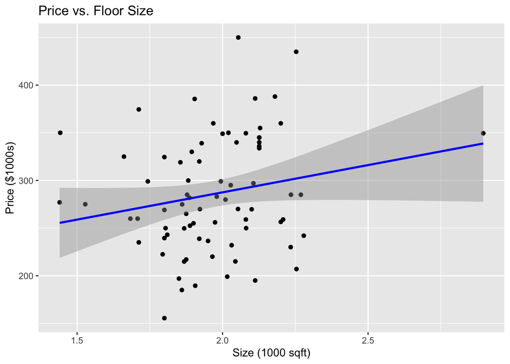

```r
# Scatter plot with regression line
ggplot(data, aes(x = Size, y = Price)) +
  geom_point() +
  geom_smooth(method = "lm", col = "blue") +
  labs(title = "Price vs. Floor Size", x = "Size (1000 sqft)", y = "Price ($1000s)")
```